# team.Rmd

Rabsa Naseer and Sierra Hoff

9/13/2020

Question 1: How are the ratings distributed? Create both a histogram and a boxplot and describe them. Don’t forget to mention outliers, if there are any.

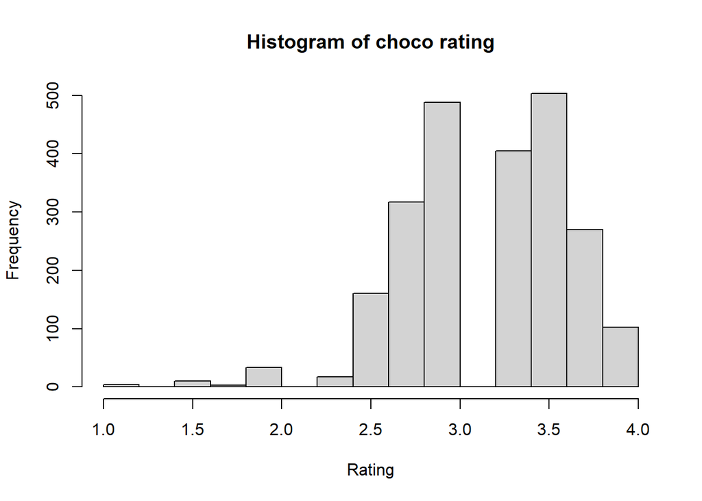

```r
choco <- read.csv("https://raw.githubusercontent.com/xdaiISU/ds202materials/master/hwlabs/data/choco.csv")
hist(choco$Rating, main= "Histogram of choco rating", xlab="Rating")
```

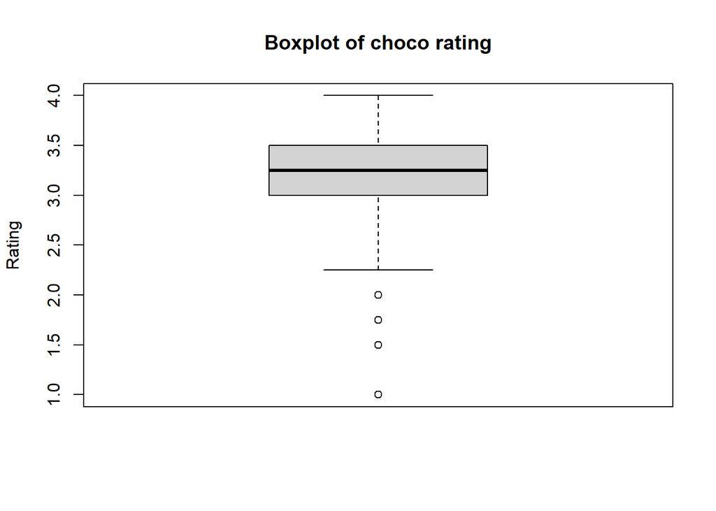

```r
boxplot(choco$Rating, main= "Boxplot of choco rating", ylab="Rating")
```

```r
summary(choco$Rating)
```

```
##    Min. 1st Qu.  Median    Mean 3rd Qu.    Max.
##   1.000   3.000   3.250   3.184   3.500   4.000
```

Question 2: How does the number of ratings depend on the year? Draw a bar chart of the number of reports.

The number of ratings seems to have mildly increased form years 2006 to 2014 before somewhat stabilizing. There were an usually low amount of ratings in 2016 and 2020 isn’t which explaines its low amount of entries.

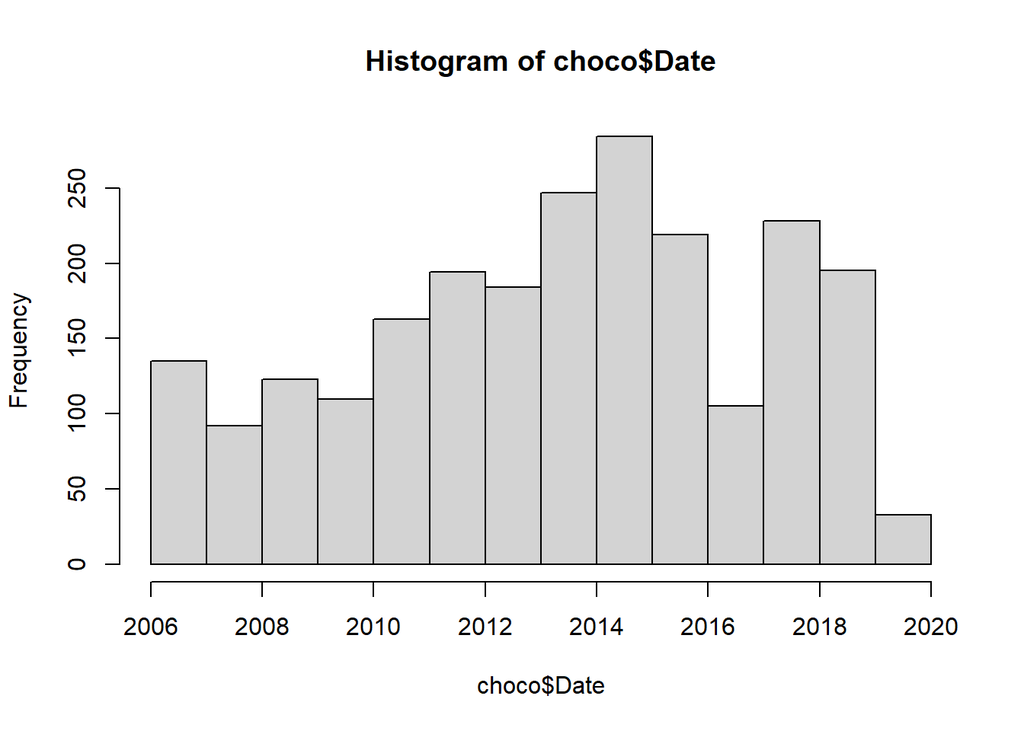

```r
choco <- read.csv("https://raw.githubusercontent.com/xdaiISU/ds202materials/master/hwlabs/data/choco.csv")
hist(choco$Date)
```

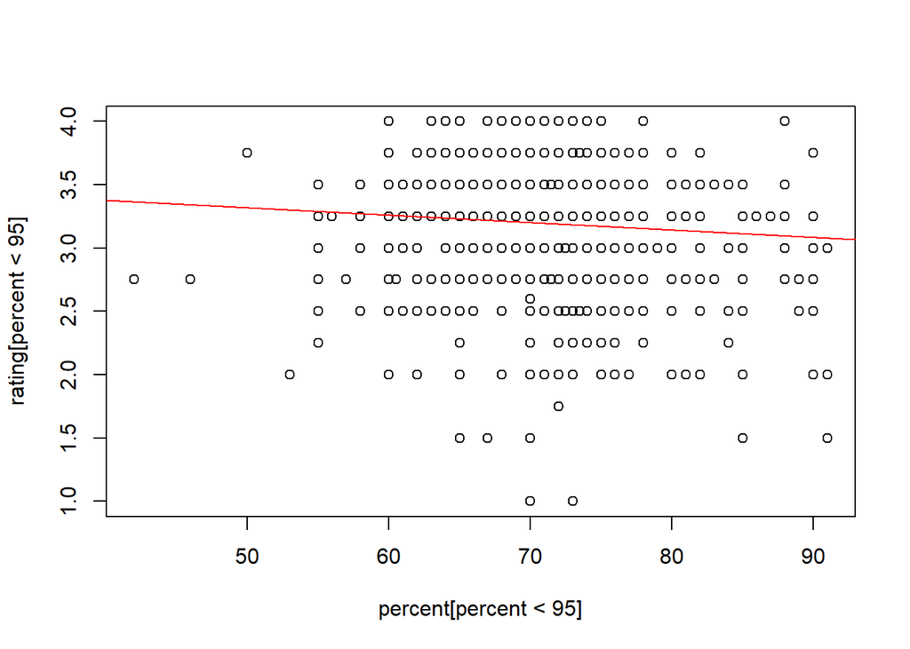

```r
choco <- read.csv("https://raw.githubusercontent.com/xdaiISU/ds202materials/master/hwlabs/data/choco.csv")
percent <- choco$Cocoa_Percent
rating <- choco$Rating
plot(percent[percent < 95], rating[percent <95])
abline(lm(rating[percent < 95] ~ percent[percent <95]), col="red")
```

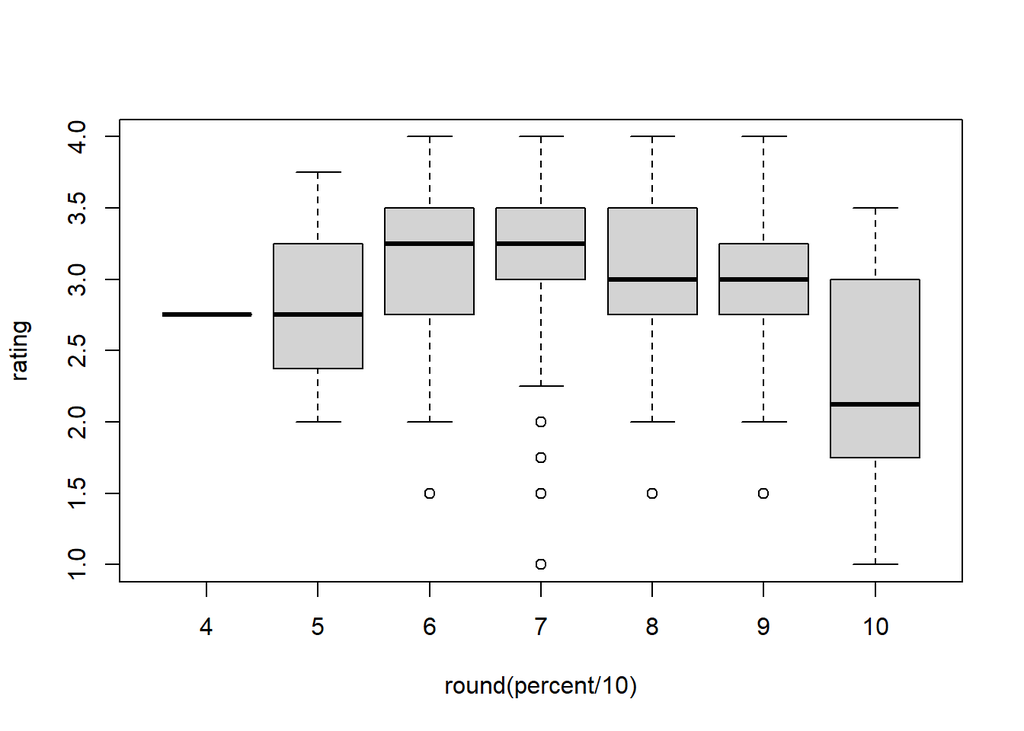

```r
boxplot(rating ~ round(percent/10))
```

```r
summary(lm(percent[percent < 95] ~ rating[percent <95]))
```

```
##
## Call:
## lm(formula = percent[percent < 95] ~ rating[percent < 95])
##
## Residuals:
##      Min       1Q   Median       3Q      Max
## -29.7190  -1.5254  -0.9447   2.8617  19.4746
##
## Coefficients:
##                      Estimate Std. Error t value Pr(>|t|)
## (Intercept)           73.8486     0.7755  95.226  < 2e-16 ***
## rating[percent < 95]  -0.7744     0.2406  -3.218  0.00131 **
## ---
## Signif. codes:  0 '***' 0.001 '**' 0.01 '*' 0.05 '.' 0.1 ' ' 1
##
## Residual standard error: 5.07 on 2288 degrees of freedom
## Multiple R-squared:  0.004506,   Adjusted R-squared:  0.004071
## F-statistic: 10.36 on 1 and 2288 DF,  p-value: 0.001308
```

```r
#r squared only
summary(lm(percent[percent < 95] ~ rating[percent <95]))$r.squared
```

```
## [1] 0.004506452
```

Queastion 4: How do different characteristics of the chocolate compare? To elaborate, which characteristics tend to be more favorable and which ones are not? Create both numerical and graphical summaries, and explain.

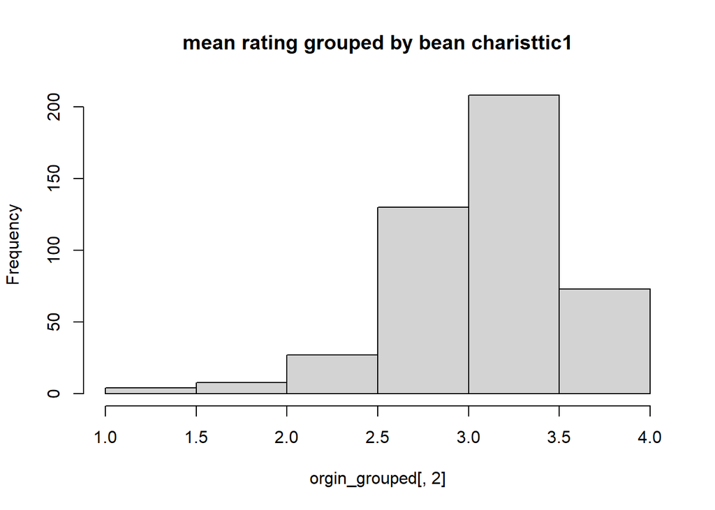

```r
choco <- read.csv("https://raw.githubusercontent.com/xdaiISU/ds202materials/master/hwlabs/data/choco.csv")
orgin_grouped <- aggregate(choco[, "Rating"], list(choco$Characteristics1), mean)
hist(orgin_grouped[,2], main ="mean rating grouped by bean charisttic1")
```

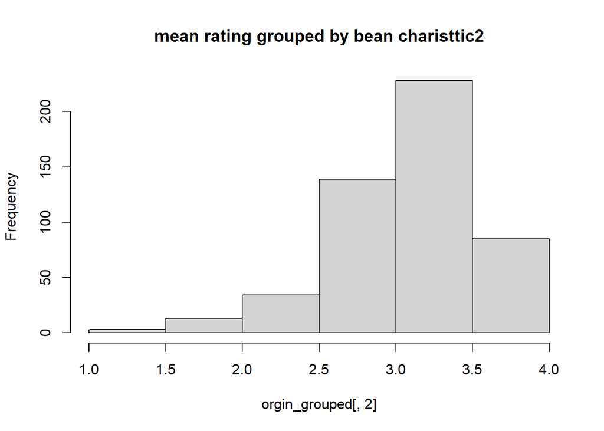

```r
orgin_grouped <- aggregate(choco[, "Rating"], list(choco$Characteristics2), mean)
hist(orgin_grouped[,2], main ="mean rating grouped by bean charisttic2")
```

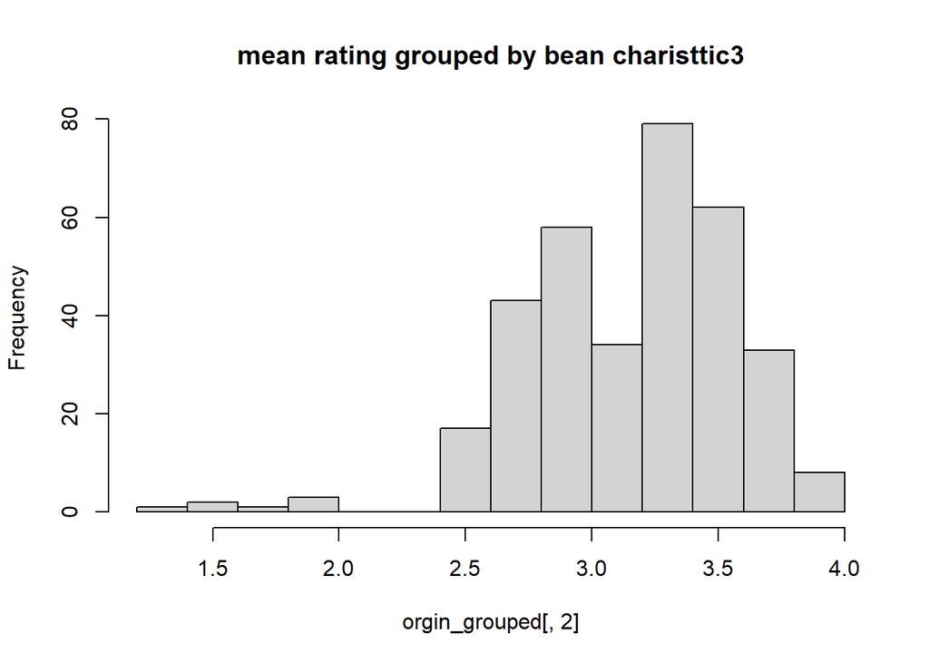

```r
orgin_grouped <- aggregate(choco[, "Rating"], list(choco$Characteristics3), mean)
hist(orgin_grouped[,2], main ="mean rating grouped by bean charisttic3")
```

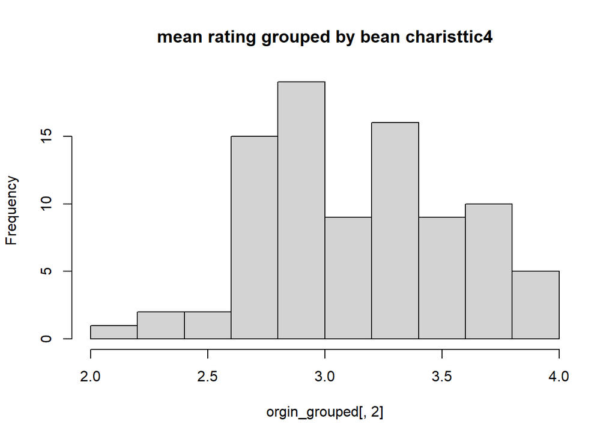

```r
orgin_grouped <- aggregate(choco[, "Rating"], list(choco$Characteristics4), mean)
hist(orgin_grouped[,2], main ="mean rating grouped by bean charisttic4")
```

```r
chars <-  aggregate(choco$Rating, by=list(Characteristics1=choco$Characteristics1), FUN=mean)
char_rates <- chars$x
names(char_rates) <- chars$Characteristics1
top15 <- head(sort(char_rates, decreasing = TRUE), n= 15)
top15
```

```
##                 cardamon chocolate covered banana           distinct lemon
##                    4.000                    4.000                    4.000
##               large nibs               ligt color                mild tart
##                    4.000                    4.000                    4.000
##         pronounced berry         simple red berry                    smoth
##                    4.000                    4.000                    4.000
##              sweet spice             well defined                   peanut
##                    4.000                    4.000                    3.875
##          appealing smoke                    apple                black tea
##                    3.750                    3.750                    3.750
```

```r
worst15 <- head(sort(char_rates, decreasing = FALSE), n= 15)
worst15
```

```
## this is not chocolate              chemical high intensity bitter
##                  1.00                  1.50                  1.50
##                klingy            very nutty  bitter coffee flavor
##                  1.50                  1.75                  2.00
##            fresh nibs               malitol  multiple off flavors
##                  2.00                  2.00                  2.00
##          non descript             sandpaper            some fruit
##                  2.00                  2.00                  2.00
##        burnt up front       extremely sweet          over roasted
##                  2.25                  2.25                  2.25
```

Question 5a: grouping the ratings by the company that made each chocolate. Then compare companies and their average, mean, ratings. This will show if the company can effect or determine good or bad ratings. This shows us the top five and worst five companies and their average ratings for their chocolates.

```r
choco <- read.csv("https://raw.githubusercontent.com/xdaiISU/ds202materials/master/hwlabs/data/choco.csv")
means <-  aggregate(choco$Rating, by=list(Company=choco$Company), FUN=mean)
rates <- means$x
names(rates) <- means$Company
top5 <- head(sort(rates, decreasing = TRUE), n= 5)
top5
```

```
##               Tobago Estate (Pralus) Heirloom Cacao Preservation (Zokoko)
##                             4.000000                             3.875000
##                               Ocelot                               Matale
##                             3.875000                             3.812500
##                               Patric
##                             3.791667
```

```r
worst5 <- head(sort(rates, decreasing = FALSE), n= 5)
worst5
```

```
##       Cote d' Or (Kraft)                Callebaut Machu Picchu Trading Co.
##                    1.000                    1.875                    1.875
##                     Casa            Jacque Torres
##                    2.000                    2.000
```

Question 5b: does where the cacao bean come from or where the chocolate is produced matter more. 5b to what degree does this matter?

It seems that in the top ten producing countries, the coco bean origin and the country where the chocolate is produced have little effect on the quality, though the country producing the chocolate has more effect baised on its greater variation in boxplots. However when the data is looked at in whole the mean value in both histograms has a range of over 1 point and it is not normally distributed like you would expect from taking means randomly from a sample.

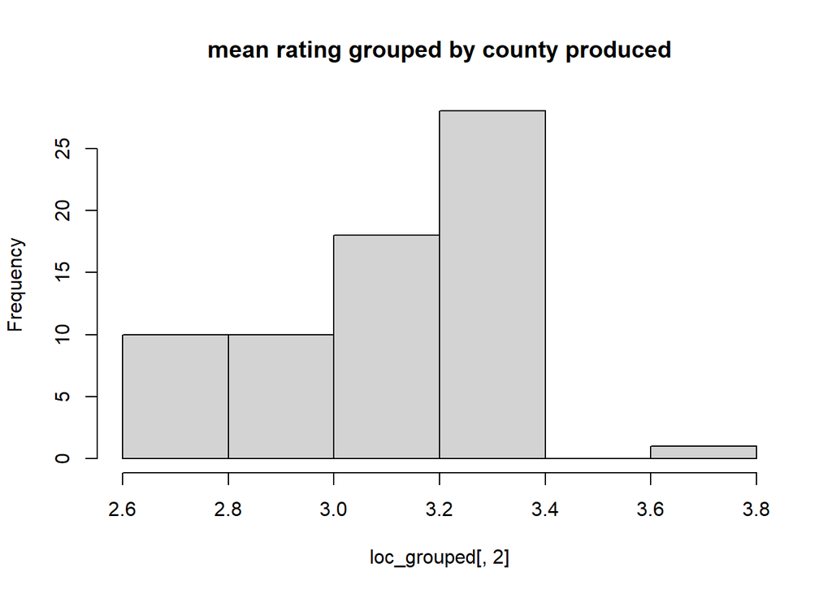

```r
choco <- read.csv("https://raw.githubusercontent.com/xdaiISU/ds202materials/master/hwlabs/data/choco.csv")
#sort(table(choco$Bean_Origin),decreasing = TRUE)
#sort(table(choco$Location),decreasing = TRUE)
location <- c("U.S.A.", "France","Canada", "U.K.", "Italy", "Belgium", "Ecuador", "Australia", "Switzerland", "Germany" )
orgin <- c("Venezuela","Peru","Ecuador","Dominican Republic","Madagascar","Blend","Nicaragua","Brazil","Bolivia","Belize")
loc_grouped <- aggregate(choco[, "Rating"], list(choco$Location), mean)
hist(loc_grouped[,2], main ="mean rating grouped by county produced")
```

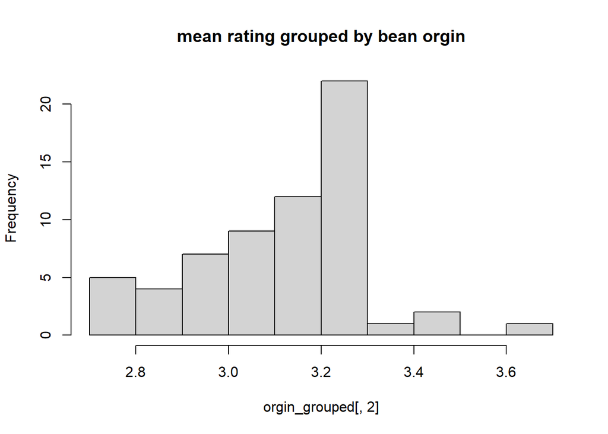

```r
orgin_grouped <- aggregate(choco[, "Rating"], list(choco$Bean_Origin), mean)
hist(orgin_grouped[,2], main ="mean rating grouped by bean orgin")
```

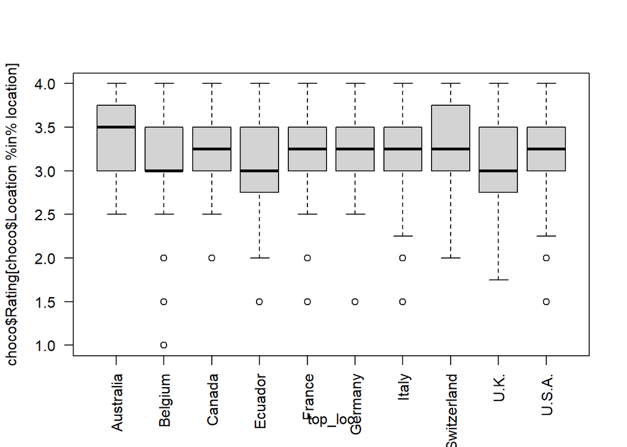

```r
top_orgin <- choco$Bean_Origin[choco$Bean_Origin %in% orgin]
top_loc <- choco$Location[choco$Location %in% location ]
boxplot(choco$Rating[choco$Location %in% location ] ~ top_loc, las=2)
```

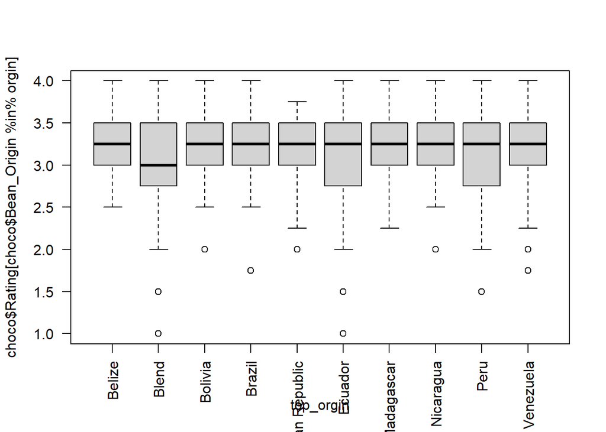

```r
boxplot(choco$Rating[choco$Bean_Origin %in% orgin ] ~ top_orgin, las=2)
```